# PopGen Problem Set 6

Mei Iwamoto

2024-12-05

1. Fruit flies can have up to 100 offspring per cross. You conduct a mono-hybrid F2 cross using lines that have an autosomal recessive mutation in the sepia gene. The cross results in 55 wildtype offspring and 27 sepia offspring. What is the binomial probability of this outcome?

monohybrid - Aa x Aa - 3 outcomes 55+27 = 82 total

2. A genetically heterogeneous population of kalo has a variance in the number of days to maturation of 40 days, whereas two inbred populations derived from it have a variance in the number of days to maturation of 10 days. What is the genetic variance (VG), the environmental variance (VE), and the broad-sense heritability (H2),for days to maturation in this population?

```r
Vp <- 40
Ve <- 10
Vg <- Vp - Ve #given both populations of kalo are growing in the same environment, the difference in days to maturation should show the difference in genetic variance between a genetically heterogeneous pop and an inbred one.


#h2 = Vg/Vp Broad sense heritability (H2) estimates the proportion of phenotypic variation that is due to total genetic variation
h2 <- Vg/Vp
print(h2)
```

```
## [1] 0.75
```

If the inbred lines were crossed, what would be the predicted variance in days to maturation of the F1 generation?

The predicted variance would be 10 because the genetic variance is 0, so Vp=Ve.

3. In a cross between two cultivated inbred varieties of tobacco, the variance in leaf number per plant in the F1 generation is 1.46 and in the F2 generation is 5.97. What are the genotypic and environmental variances? What is the broad-sense heritability in leaf number? Show your work.

```r
vet <- 1.46 #environmental variance because the F1 generation is genetically uniform since it comes from two cultivated inbred varieties of tobacco

#the genetic variance of the F1 generation is 0

vgt <- 5.97 - vet #genetic variance of F2 generation
vpt <- 5.97 #total phenotypic variance of F2 generation
h2tf2 <- vgt/vpt #broad-sense heritability of F2 generation
print(h2tf2)
```

```
## [1] 0.7554439
```

```r
h2tf2 <- 0/1.46 #broad-sense heritability of F1 generation
```

4. Write a simulation in R to illustrate the process of genetic drift for five alleles, each with an initial frequency of p=0.05, for a population size of 100 and 1000. Modify your simulation to incorporate selection on these variants, assuming that selection is either purifying, positive, or effectively neutral. For each population size, plot all simulations on a single graph and label all axes. Write a few sentences on how selection can influence the probability of fixation as population size changes. Your answer will be your code and graphs, and your explanation.

For population size of 100:

```r
#make a matrix for each allele, 200 rows for the number of alleles in each population (100x2), 100 columns for number of generations. pop size = 100
a1 <- matrix(data = NA, nrow = 200, ncol = 100)
a2 <- matrix(data = NA, nrow = 200, ncol = 100)
a3 <- matrix(data = NA, nrow = 200, ncol = 100)
a4 <- matrix(data = NA, nrow = 200, ncol = 100)
a5 <- matrix(data = NA, nrow = 200, ncol = 100)

#afreq will calculate frequency of allele a in the population over time (columns here for simulations)
afreq <- matrix(data=NA, nrow=100, ncol=5)

sam <- matrix(data=NA, nrow=200, ncol=5)

for (m in 1:5) {
  sam[1:200, m] <- sample(c("a","A"), size = 200, replace=T, prob=c(0.7,0.3))

}
```

```r
#first simulation
a1[1:200, 1] <- sam[,1]

#sample from the initial starting out population for the rest of the generations
for (i in 1:99) {
  a1[1:200, 1+i] <- sample(a1[1:200, i], size=200, replace=T)
  afreq[i,1] <- (length(a1[a1[1:200, i]=="a"])/20000)
}

#second simulation
a2[1:200, 1] <- sam[,2]

for (i in 1:99) {
  a2[1:200, 1+i] <- sample(a2[1:200, i], size=200, replace=T)
  afreq[i,2] <- (length(a2[a2[1:200, i]=="a"])/20000)
}


#third simulation
a3[1:200, 1] <- sam[,3]

for (i in 1:99) {
  a3[1:200, 1+i] <- sample(a3[1:200, i], size=200, replace=T)
  afreq[i,3] <- (length(a3[a3[1:200, i]=="a"])/20000)
}


#fourth simulation
a4[1:200, 1] <- sam[,4]

for (i in 1:99) {
  a4[1:200, 1+i] <- sample(a4[1:200, i], size=200, replace=T)
  afreq[i,4] <- (length(a4[a4[1:200, i]=="a"])/20000)
}


#fifth simulation
a5[1:200, 1] <- sam[,5]

for (i in 1:99) {
  a5[1:200, 1+i] <- sample(a5[1:200, i], size=200, replace=T)
  afreq[i,5] <- (length(a5[a5[1:200, i]=="a"])/20000)
}
```

Plot five alleles

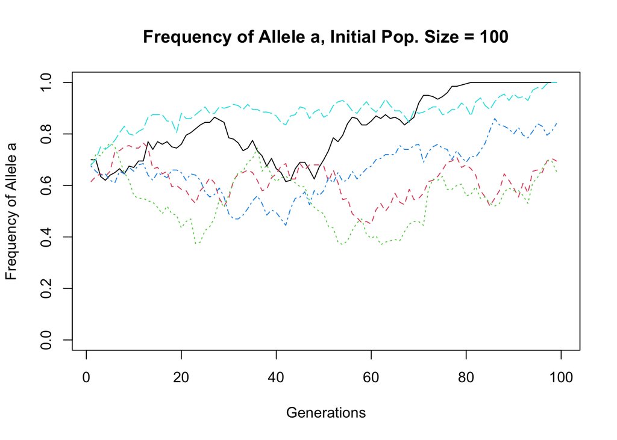

```r
#use matplot for plotting matrices
matplot(afreq, type = 'l', xlab = 'Generations', ylab='Frequency of Allele a', main='Frequency of Allele a, Initial Pop. Size = 100', ylim=c(0,1))
```

For population of 1000:

```r
b1 <- matrix(data = NA, nrow = 2000, ncol = 100)
b2 <- matrix(data = NA, nrow = 2000, ncol = 100)
b3 <- matrix(data = NA, nrow = 2000, ncol = 100)
b4 <- matrix(data = NA, nrow = 2000, ncol = 100)
b5 <- matrix(data = NA, nrow = 2000, ncol = 100)

#afreq will calculate frequency of allele a in the population over time (columns here for simulations)
bfreq <- matrix(data=NA, nrow=100, ncol=5)

samb <- matrix(data=NA, nrow=2000, ncol=5)

for (m in 1:5) {
  samb[1:2000, m] <- sample(c("a","A"), size = 2000, replace=T, prob=c(0.7,0.3))

}


#first simulation
b1[1:2000, 1] <- samb[,1]

#sample from the initial starting out population for the rest of the generations
for (i in 1:99) {
  b1[1:2000, 1+i] <- sample(b1[1:2000, i], size=2000, replace=T)
  bfreq[i,1] <- (length(b1[b1[1:2000, i]=="a"])/200000)
}

#second simulation
b2[1:2000, 1] <- samb[,2]

for (i in 1:99) {
  b2[1:2000, 1+i] <- sample(b2[1:2000, i], size=2000, replace=T)
  bfreq[i,2] <- (length(b2[b2[1:2000, i]=="a"])/200000)
}


#third simulation
b3[1:2000, 1] <- samb[,3]

for (i in 1:99) {
  b3[1:2000, 1+i] <- sample(b3[1:2000, i], size=2000, replace=T)
  bfreq[i,3] <- (length(b3[b3[1:2000, i]=="a"])/200000)
}


#fourth simulation
b4[1:2000, 1] <- samb[,4]

for (i in 1:99) {
  b4[1:2000, 1+i] <- sample(b4[1:2000, i], size=2000, replace=T)
  bfreq[i,4] <- (length(b4[b4[1:2000, i]=="a"])/200000)
}


#fifth simulation
b5[1:2000, 1] <- samb[,5]

for (i in 1:99) {
  b5[1:2000, 1+i] <- sample(b5[1:2000, i], size=2000, replace=T)
  bfreq[i,5] <- (length(b5[b5[1:2000, i]=="a"])/200000)
}
```

Plot five alleles

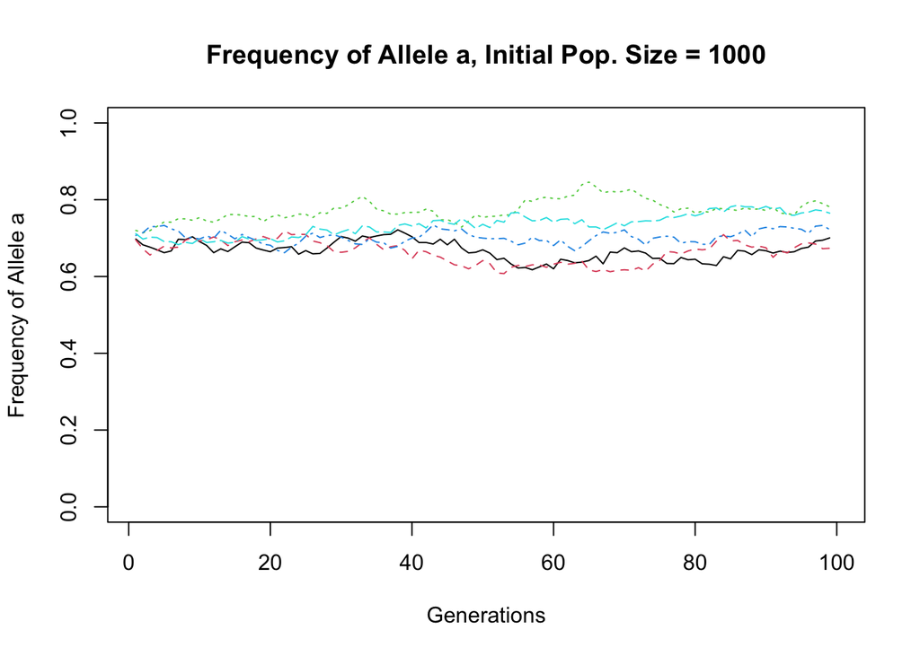

```r
#use matplot for plotting matrices
matplot(bfreq, type = 'l', xlab = 'Generations', ylab='Frequency of Allele a', main='Frequency of Allele a, Initial Pop. Size = 1000', ylim=c(0,1))
```

Write a few sentences on how selection can influence the probability of fixation as population size changes.

Although my plots don’t show this very well, larger population sizes would mean that beneficial alleles have a greater chance of becoming fixed through selection. With a larger pop size, there is also less of a chance of genetic drift randomly losing the beneficial allele from the population before it can get fixed.